# Assignment 6: SVD Regression and Step-Wise Regression

Univeristy of Washington - Data Science Certification - Method for Data Analysis

Josh Jensen

August 14, 2016

### Assignment

Perform SVD regression on the auto price data:

- Use the following features for your initial model: make, fuel.type, aspiration, body.style, drive.wheels, length, curb.weight, engine.type, num.of.cylinders, engine.size, city.mpg
- Apply SVD to a model matrix created with model.matrix(), and report the increase in dimensionality
- Report how many orthogonal features you used for you model
- Evaluate your model performance with plots and by computing RMS error. Hint see my demo code for plots

Use stepwise regression to select features from the aforementioned set:

- Compare model performance with full model using summary statistics, plots and ANOVA

### Conclusions

I run SVD regression (total least squares regression) to predict auto price. I leverage SVD to conduct feature reduction.

Further, I run stepwise regression on the feature set to also predict auto price. I find no statistical difference between the linear model containing all specified features and a stepwise iteration.

### Set up & cleaning

First lets load libraries and data.

```r
# load libraries and set working drive
library(dplyr)
library(readr)
library(ggplot2)

# read in data
auto_prices <- read_csv('Automobile price data _Raw_.csv', na = c('','?'))
```

Subset and clean data set to make it easier to work with and inspect.

```r
# rename columns
colnames(auto_prices) <- gsub('-','_', colnames(auto_prices))

# create log price
auto_prices$log_price <- log(auto_prices$price)

# subset down to columns of interest
# make, fuel_type, aspiration, body_style, drive_wheels, length, curb_weight, engine_type, num_of_cylinders, engine_size, city_mpg
vars <- c("make", "fuel_type", "aspiration", "body_style", "drive_wheels", "length", "curb_weight", "engine_type", "num_of_cylinders", "engine_size", "city_mpg")
auto_prices <- select(auto_prices, log_price, one_of(vars))

# note svd requires fully balanced data set, so lets remove na's
auto_prices <- na.omit(auto_prices)

# inspection of structure
str(auto_prices)
```

```
## Classes 'tbl_df' and 'data.frame':   201 obs. of  12 variables:
##  $ log_price       : num  9.51 9.71 9.71 9.54 9.77 ...
##  $ make            : chr  "alfa-romero" "alfa-romero" "alfa-romero" "audi" ...
##  $ fuel_type       : chr  "gas" "gas" "gas" "gas" ...
##  $ aspiration      : chr  "std" "std" "std" "std" ...
##  $ body_style      : chr  "convertible" "convertible" "hatchback" "sedan" ...
##  $ drive_wheels    : chr  "rwd" "rwd" "rwd" "fwd" ...
##  $ length          : num  169 169 171 177 177 ...
##  $ curb_weight     : int  2548 2548 2823 2337 2824 2507 2844 2954 3086 2395 ...
##  $ engine_type     : chr  "dohc" "dohc" "ohcv" "ohc" ...
##  $ num_of_cylinders: chr  "four" "four" "six" "four" ...
##  $ engine_size     : int  130 130 152 109 136 136 136 136 131 108 ...
##  $ city_mpg        : int  21 21 19 24 18 19 19 19 17 23 ...
##  - attr(*, "na.action")=Class 'omit'  Named int [1:4] 10 45 46 130
##   .. ..- attr(*, "names")= chr [1:4] "10" "45" "46" "130"
```

### SVD Regression

#### Create model matrix

First lets inspect the number of dimensions in the auto price data frame.

```r
dim(auto_prices)
```

```
## [1] 201  12
```

Note that there are 11 features and 1 outcome measure across 201 observations. Now lets create the model matrix and inspect the number of dimensions.

```r
# create model matrix
ap_matrix <- model.matrix(log_price ~ . , auto_prices)

# inspect number of dimensions in matrix
dim(ap_matrix)
```

```
## [1] 201  45
```

Note that in the transformed matrix there are 45 orthogonal features. Further the outcome measure is not included in matrix.

#### Run SVD Regression

First compute the singular value decomposition (SVD) of the feature matrix.

```r
ap_svd <- svd(ap_matrix)
```

Now compute the inverse of the singular values.

```r
d_inverse <- diag(1/ap_svd$d)
```

Next compute the psuedo inverse.

```r
psuedo_inverse <- ap_svd$v %*% t(d_inverse) %*% t(ap_svd$u)
```

Before moving on lets verify the correct calculation of puesdo matrix by inspecting if it yeilds approximately an identity matrix.

```r
test <- psuedo_inverse %*% (ap_svd$u %*% diag(ap_svd$d) %*% t(ap_svd$v))
head(test, n = 3)
```

```
##               [,1]          [,2]          [,3]          [,4]          [,5]
## [1,]  1.000000e+00 -1.579974e-15  1.300173e-15  2.581392e-15 -4.604766e-15
## [2,]  7.976259e-15  1.000000e+00 -1.550546e-14 -5.436850e-15  6.900207e-16
## [3,] -8.968520e-16  1.861798e-15  1.000000e+00  2.249794e-15  3.995210e-16
##               [,6]          [,7]          [,8]         [,9]        [,10]
## [1,] -1.657881e-14 -2.125785e-15 -1.855938e-15 4.326511e-15 1.311725e-15
## [2,]  5.037174e-15 -3.680364e-16 -3.102060e-15 6.581077e-15 7.028370e-16
## [3,]  3.617040e-15 -9.763211e-17 -1.931060e-15 4.193398e-15 1.177766e-15
##              [,11]         [,12]         [,13]        [,14]         [,15]
## [1,]  8.055663e-16 -2.366605e-17  1.360615e-14 3.635747e-15  2.574069e-15
## [2,] -2.677154e-16 -1.670909e-15 -3.665958e-15 3.999921e-15 -1.611208e-15
## [3,] -2.335496e-16 -1.636434e-15 -5.130453e-15 4.216345e-15 -2.769755e-15
##             [,16]         [,17]         [,18]         [,19]         [,20]
## [1,] 1.031821e-15 -2.091258e-16 -1.017324e-15 -3.169802e-15 -2.713123e-17
## [2,] 3.338353e-15 -5.723866e-16 -1.210344e-15 -1.022984e-16  3.731465e-15
```

[output cut: 21 more lines]

Confirmed.

Now we find model coefficients by multiplying against the outcome variable vector.

```r
ap_coef <- psuedo_inverse %*% as.matrix(auto_prices$log_price)
t(ap_coef)
```

```
##          [,1]      [,2]      [,3]        [,4]       [,5]        [,6]
## [1,] 8.055077 0.2202901 0.3241553 -0.06309514 -0.1633678 -0.03666645
##            [,7]       [,8]        [,9]       [,10]      [,11]      [,12]
## [1,] -0.3928072 -0.1637711 -0.06007415 -0.03146955 -0.1277188 -0.2248945
##           [,13]       [,14]      [,15]     [,16]     [,17]      [,18]
## [1,] -0.0914963 -1820717673 -0.2096363 0.3552928 -0.172177 0.01648146
##           [,19]      [,20]      [,21]       [,22]       [,23]     [,24]
## [1,] -0.5167299 -0.1716198 -0.0542685 -0.06746059 -0.03452456 0.1042318
##           [,25]      [,26]      [,27]      [,28]      [,29]     [,30]
## [1,] -0.1371821 -0.1378398 -0.1168178 -0.2194984 0.04296234 0.1347668
##            [,31]        [,32]      [,33]       [,34]     [,35]       [,36]
## [1,] 0.002161291 0.0005717426 1820717672 -0.02773929 0.3356731 -0.07175556
##             [,37]      [,38]      [,39]     [,40]       [,41]       [,42]
## [1,] -25102630273 -0.2486138 -0.2236324 -0.221098 -1820717673 -0.05808858
##            [,43]        [,44]        [,45]
## [1,] 25102630273 0.0005381598 -0.008615552
```

Lets repeat the SVD regression, but now apply dimensionality reduction to produce our final model.

```r
# reduce dimensionality by removing the least stable singular vectors
d_reduced <- ifelse(1/ap_svd$d > 0.5, 0, 1/ap_svd$d)
d_inverse2 <- diag(d_reduced)
```

Compute the number of orthogonal features used in the final model.

```r
length(d_reduced[d_reduced > 0])
```

```
## [1] 26
```

Calculate the coeffients of the final SVD regression model.

```r
psuedo_inverse2 <- ap_svd$v %*% t(d_inverse2) %*% t(ap_svd$u)

ap_coef2 <- psuedo_inverse2 %*% as.matrix(auto_prices$log_price)
t(ap_coef2)
```

```
##          [,1]      [,2]        [,3]       [,4]      [,5]     [,6]
## [1,] 0.121726 0.0289911 -0.04319819 0.02650467 0.2177419 0.259908
##            [,7]       [,8]       [,9]       [,10]      [,11]      [,12]
## [1,] 0.06633081 0.04132819 0.06993529 -0.07070383 0.04217337 0.03810701
##           [,13]      [,14]      [,15]     [,16]       [,17]       [,18]
## [1,] -0.0337416 -0.2193899 0.01245444 0.2290097 -0.08944241 -0.06980753
##           [,19]      [,20]     [,21]      [,22]     [,23]     [,24]
## [1,] -0.0520445 -0.1979581 0.1545512 -0.3579036 0.5360438 0.2540819
##          [,25]      [,26]      [,27]      [,28]      [,29]     [,30]
## [1,] 0.2927998 0.02361188 -0.1003267 -0.2732715 -0.1725248 0.1186092
##           [,31]        [,32]      [,33]      [,34]     [,35]       [,36]
## [1,] 0.04042635 0.0003515806 -0.2170073 0.02270641 0.1466836 -0.07702572
##           [,37]      [,38]      [,39]     [,40]       [,41]      [,42]
## [1,] 0.07433506 0.05321367 -0.1258426 0.2186713 0.002382589 -0.0196364
##           [,43]         [,44]      [,45]
## [1,] 0.07433506 -0.0002138672 0.03902244
```

#### Evaluate model

Now lets evaluate our model by running diagnostics by looking at residuals and calculating RMSE. First we need to calculate predicted and residual values.

```r
auto_prices$pred <- ap_matrix %*% ap_coef2
auto_prices$resid <- auto_prices$pred - auto_prices$log_price
```

Leverage Prof. Steve Elston’s diagnositic plots to inspect the residuals.

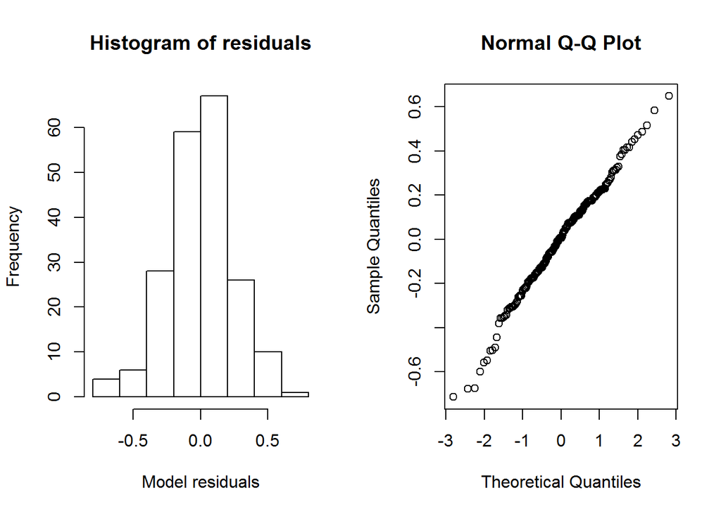

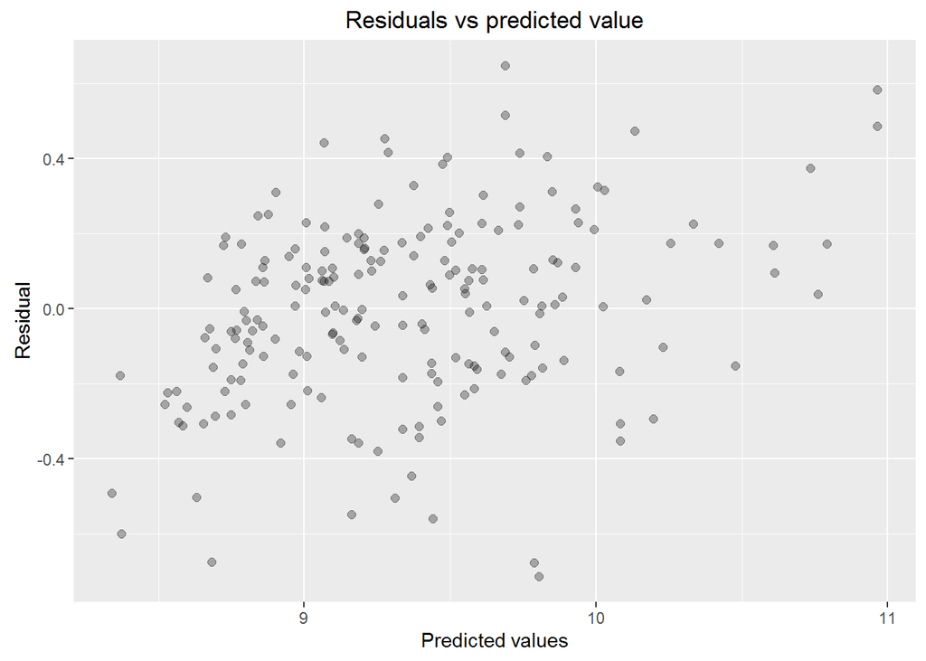

```r
# shamelessly lifting Prof. Steve Elston's diagnositic plots, found here:
# https://github.com/StephenElston/DataScience350/blob/master/Lecture6/SVDReg.R
plot.diagnostic = function(df){
  ## Plot the histogram and Q-Q of the residuals
  par(mfrow = c(1,2))
  hist(df$resid,
       main = 'Histogram of residuals',
       xlab = 'Model residuals')
  qqnorm(df$resid)
  par(mfrow = c(1,1))

  ## Plot the residuals vs the predicted values
  require(ggplot2)
  ggplot(df, aes(pred, resid)) +
    geom_point(size = 2, alpha = 0.3) +
    ggtitle('Residuals vs predicted value') +
    xlab('Predicted values') + ylab('Residual')
}

# run diagnostic plots
plot.diagnostic(auto_prices)
```

Plots indicate no obvious issues with the assumed normality of the residuals.

Finally we compute the RMSE.

```r
rmse <- sqrt(mean(auto_prices$resid^2))
rmse
```

```
## [1] 0.2427033
```

### Stepwise Regression

Now lets use the stepwise regression as a means of feature selection. First we need to clean up the data frame and drop `pred` & `resid` values.

```r
auto_prices <- dplyr::select(auto_prices, -pred, -resid)
```

Now as a baseline, we fit the full model.

```r
ap_lm <- lm(log_price ~ ., data = auto_prices)

summary(ap_lm)
```

```
##
## Call:
## lm(formula = log_price ~ ., data = auto_prices)
##
## Residuals:
##      Min       1Q   Median       3Q      Max
## -0.28217 -0.05438 -0.00177  0.05925  0.32142
##
## Coefficients: (2 not defined because of singularities)
##                          Estimate Std. Error t value Pr(>|t|)
## (Intercept)             8.055e+00  4.536e-01  17.757  < 2e-16 ***
## makeaudi                2.203e-01  1.254e-01   1.757  0.08088 .
## makebmw                 3.242e-01  1.154e-01   2.809  0.00560 **
## makechevrolet          -6.310e-02  1.267e-01  -0.498  0.61908
## makedodge              -1.634e-01  1.008e-01  -1.620  0.10715
## makehonda              -3.666e-02  9.771e-02  -0.375  0.70805
## makeisuzu              -3.928e-01  1.251e-01  -3.139  0.00202 **
## makejaguar             -1.638e-01  1.491e-01  -1.098  0.27373
## makemazda              -6.008e-02  9.457e-02  -0.635  0.52613
## makemercedes-benz      -3.146e-02  1.480e-01  -0.213  0.83191
## makemercury            -1.277e-01  1.533e-01  -0.833  0.40600
## makemitsubishi         -2.249e-01  9.895e-02  -2.273  0.02440 *
## makenissan             -9.151e-02  9.076e-02  -1.008  0.31486
## makepeugot             -2.520e-01  2.339e-01  -1.077  0.28301
## makeplymouth           -2.096e-01  1.013e-01  -2.070  0.04006 *
## makeporsche             3.553e-01  1.533e-01   2.318  0.02176 *
## makerenault            -1.722e-01  1.237e-01  -1.391  0.16606
## makesaab                1.648e-02  1.054e-01   0.156  0.87597
## makesubaru             -5.167e-01  1.884e-01  -2.743  0.00680 **
## maketoyota             -1.716e-01  8.852e-02  -1.939  0.05433 .
## makevolkswagen         -5.426e-02  9.469e-02  -0.573  0.56748
## makevolvo              -6.745e-02  1.038e-01  -0.650  0.51677
## fuel_typegas           -3.453e-02  5.648e-02  -0.611  0.54189
## aspirationturbo         1.042e-01  3.387e-02   3.078  0.00246 **
## body_stylehardtop      -1.372e-01  7.569e-02  -1.812  0.07185 .
## body_stylehatchback    -1.378e-01  6.793e-02  -2.029  0.04415 *
## body_stylesedan        -1.168e-01  7.087e-02  -1.648  0.10128
## body_stylewagon        -2.195e-01  7.485e-02  -2.932  0.00386 **
## drive_wheelsfwd         4.298e-02  5.613e-02   0.766  0.44500
## drive_wheelsrwd         1.348e-01  6.525e-02   2.065  0.04052 *
## length                  2.161e-03  2.599e-03   0.832  0.40691
## curb_weight             5.744e-04  9.856e-05   5.828 3.05e-08 ***
## engine_typel           -1.031e-01  2.240e-01  -0.461  0.64577
## engine_typeohc         -2.775e-02  5.691e-02  -0.487  0.62658
## engine_typeohcf         3.357e-01  1.608e-01   2.088  0.03842 *
## engine_typeohcv        -7.175e-02  7.613e-02  -0.943  0.34736
## engine_typerotor       -1.375e-01  2.132e-01  -0.645  0.51978
## num_of_cylindersfive   -2.486e-01  1.429e-01  -1.740  0.08381 .
## num_of_cylindersfour   -2.236e-01  1.712e-01  -1.306  0.19350
## num_of_cylinderssix    -2.211e-01  1.539e-01  -1.436  0.15284
## num_of_cylindersthree          NA         NA      NA       NA
## num_of_cylinderstwelve -5.806e-02  2.040e-01  -0.285  0.77630
## num_of_cylinderstwo            NA         NA      NA       NA
## engine_size             5.369e-04  9.595e-04   0.560  0.57656
## city_mpg               -8.617e-03  4.079e-03  -2.112  0.03625 *
## ---
## Signif. codes:  0 '***' 0.001 '**' 0.01 '*' 0.05 '.' 0.1 ' ' 1
##
## Residual standard error: 0.1161 on 158 degrees of freedom
## Multiple R-squared:  0.9578, Adjusted R-squared:  0.9466
## F-statistic: 85.33 on 42 and 158 DF,  p-value: < 2.2e-16
```

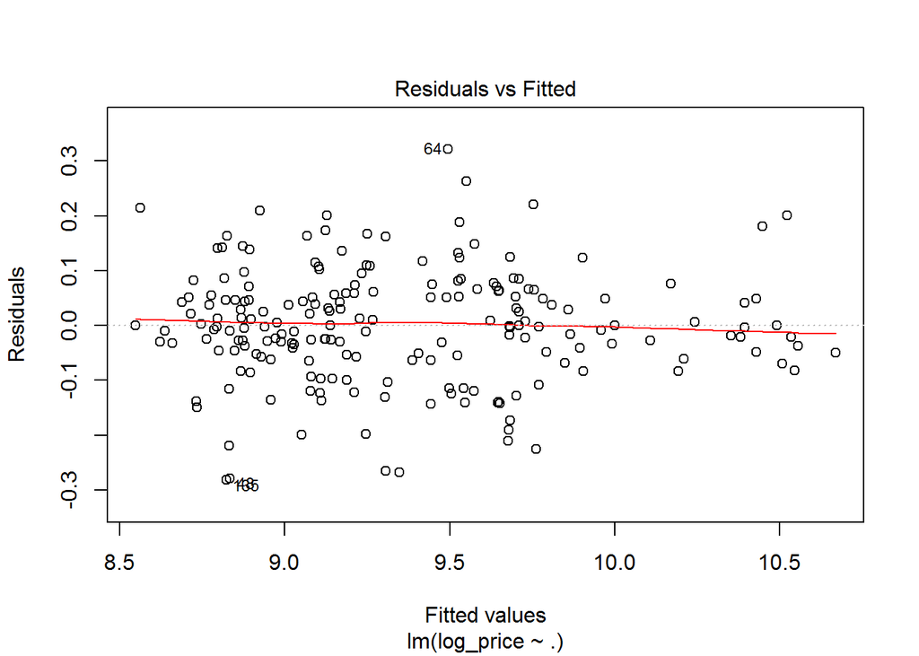

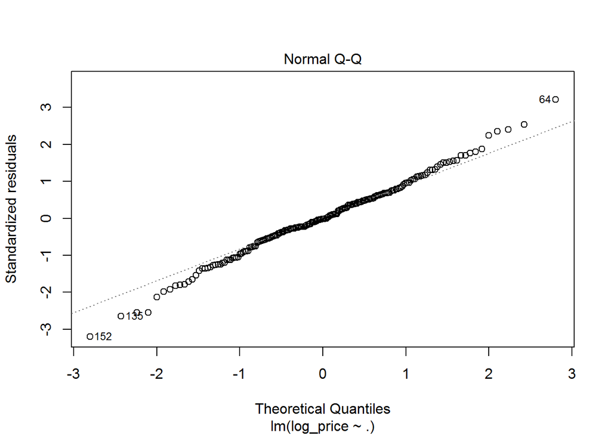

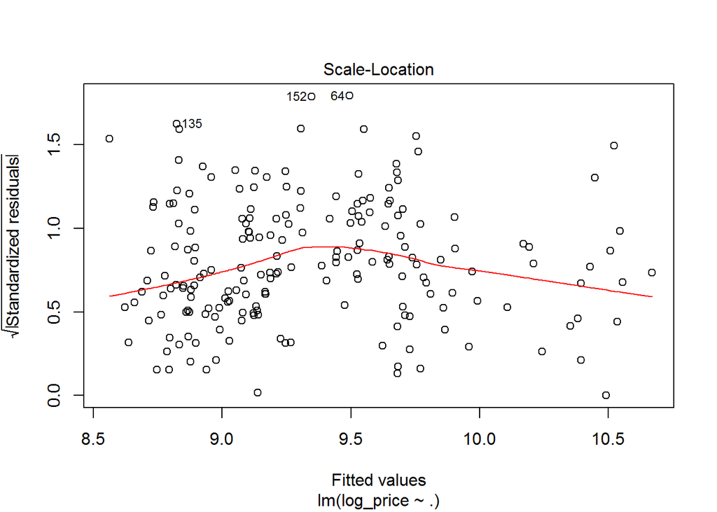

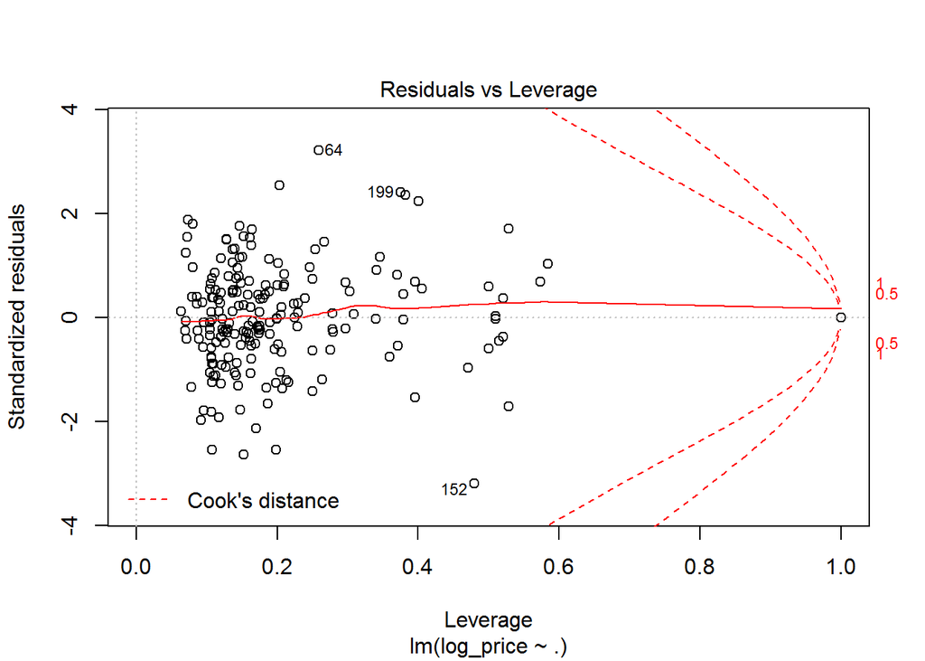

```r
plot(ap_lm)
```

Using the full model we then use the `stepAIC` function to run stepwise regression.

```r
# fit step wise
library(MASS)
ap_lmstep <- stepAIC(ap_lm, direction = 'both')
```

```
## Start:  AIC=-827.97
## log_price ~ make + fuel_type + aspiration + body_style + drive_wheels +
##     length + curb_weight + engine_type + num_of_cylinders + engine_size +
##     city_mpg
##
##                    Df Sum of Sq    RSS     AIC
## - num_of_cylinders  4   0.05410 2.1843 -830.92
## - engine_size       1   0.00422 2.1344 -829.57
## - fuel_type         1   0.00504 2.1352 -829.49
## - length            1   0.00932 2.1395 -829.09
## <none>                          2.1302 -827.97
## - engine_type       3   0.08731 2.2175 -825.89
## - drive_wheels      2   0.07936 2.2096 -824.61
## - city_mpg          1   0.06015 2.1903 -824.37
## - aspiration        1   0.12772 2.2579 -818.26
## - body_style        4   0.22035 2.3505 -816.18
## - curb_weight       1   0.45799 2.5882 -790.82
## - make             20   2.50799 4.6382 -711.57
##
## Step:  AIC=-830.92
## log_price ~ make + fuel_type + aspiration + body_style + drive_wheels +
##     length + curb_weight + engine_type + engine_size + city_mpg
##
##                    Df Sum of Sq    RSS     AIC
## - fuel_type         1    0.0004 2.1847 -832.89
## - length            1    0.0211 2.2054 -830.99
## <none>                          2.1843 -830.92
## - drive_wheels      2    0.0664 2.2507 -828.90
## - city_mpg          1    0.0443 2.2286 -828.89
## - engine_size       1    0.0448 2.2291 -828.84
## + num_of_cylinders  4    0.0541 2.1302 -827.97
## - engine_type       5    0.1546 2.3389 -827.18
## - aspiration        1    0.1556 2.3399 -819.09
## - body_style        4    0.2549 2.4392 -816.74
## - curb_weight       1    0.4333 2.6176 -796.55
## - make             21    3.6261 5.8104 -676.28
##
## Step:  AIC=-832.89
## log_price ~ make + aspiration + body_style + drive_wheels + length +
##     curb_weight + engine_type + engine_size + city_mpg
```

[output cut: 17 more lines]

```
##     engine_type + engine_size + city_mpg
##
##                    Df Sum of Sq    RSS     AIC
## <none>                          2.2057 -832.97
## + length            1    0.0210 2.1847 -832.89
## - drive_wheels      2    0.0641 2.2698 -831.21
## + fuel_type         1    0.0002 2.2054 -830.99
## + num_of_cylinders  4    0.0608 2.1449 -830.59
## - engine_size       1    0.0563 2.2620 -829.90
## - engine_type       5    0.1546 2.3602 -829.35
## - city_mpg          1    0.1019 2.3076 -825.89
## - body_style        4    0.2427 2.4483 -819.99
## - aspiration        1    0.1789 2.3846 -819.29
## - curb_weight       1    0.9319 3.1375 -764.13
## - make             21    3.7055 5.9111 -676.82
```

```r
summary(ap_lmstep)
```

```
##
## Call:
## lm(formula = log_price ~ make + aspiration + body_style + drive_wheels +
##     curb_weight + engine_type + engine_size + city_mpg, data = auto_prices)
##
## Residuals:
##      Min       1Q   Median       3Q      Max
## -0.29191 -0.05628  0.00000  0.06497  0.34357
##
## Coefficients:
##                       Estimate Std. Error t value Pr(>|t|)
## (Intercept)          8.057e+00  1.831e-01  44.003  < 2e-16 ***
## makeaudi             2.402e-01  1.034e-01   2.323 0.021428 *
## makebmw              3.458e-01  1.026e-01   3.372 0.000930 ***
## makechevrolet       -7.043e-02  1.200e-01  -0.587 0.558203
## makedodge           -1.575e-01  9.511e-02  -1.656 0.099701 .
## makehonda           -3.203e-02  9.216e-02  -0.348 0.728655
## makeisuzu           -3.512e-01  1.200e-01  -2.927 0.003910 **
## makejaguar          -1.687e-01  1.287e-01  -1.311 0.191722
## makemazda           -3.395e-02  9.211e-02  -0.369 0.712908
## makemercedes-benz    6.578e-02  1.019e-01   0.646 0.519432
## makemercury         -7.469e-02  1.476e-01  -0.506 0.613601
## makemitsubishi      -2.082e-01  9.440e-02  -2.206 0.028792 *
## makenissan          -9.605e-02  8.826e-02  -1.088 0.278066
## makepeugot          -3.785e-01  1.773e-01  -2.135 0.034284 *
## makeplymouth        -1.960e-01  9.642e-02  -2.033 0.043651 *
## makeporsche          3.735e-01  1.477e-01   2.528 0.012405 *
## makerenault         -1.481e-01  1.224e-01  -1.210 0.228145
## makesaab             7.788e-02  1.007e-01   0.773 0.440562
## makesubaru          -4.513e-01  1.754e-01  -2.573 0.010956 *
## maketoyota          -1.461e-01  8.439e-02  -1.731 0.085307 .
## makevolkswagen      -2.422e-02  9.171e-02  -0.264 0.792075
## makevolvo           -1.448e-02  9.600e-02  -0.151 0.880287
## aspirationturbo      1.042e-01  2.856e-02   3.648 0.000355 ***
## body_stylehardtop   -1.531e-01  6.990e-02  -2.190 0.029970 *
## body_stylehatchback -1.581e-01  6.124e-02  -2.581 0.010732 *
## body_stylesedan     -1.192e-01  6.053e-02  -1.969 0.050670 .
## body_stylewagon     -2.139e-01  6.576e-02  -3.253 0.001387 **
## drive_wheelsfwd      4.061e-02  5.209e-02   0.780 0.436792
## drive_wheelsrwd      1.195e-01  6.229e-02   1.919 0.056706 .
## curb_weight          5.546e-04  6.663e-05   8.324 3.17e-14 ***
## engine_typel         9.729e-02  1.531e-01   0.635 0.526080
## engine_typeohc      -3.523e-02  4.826e-02  -0.730 0.466465
## engine_typeohcf      2.782e-01  1.529e-01   1.820 0.070639 .
## engine_typeohcv     -4.337e-02  6.289e-02  -0.690 0.491444
## engine_typerotor     1.495e-01  9.427e-02   1.586 0.114749
## engine_size          1.593e-03  7.784e-04   2.046 0.042352 *
## city_mpg            -7.271e-03  2.641e-03  -2.753 0.006573 **
## ---
## Signif. codes:  0 '***' 0.001 '**' 0.01 '*' 0.05 '.' 0.1 ' ' 1
##
## Residual standard error: 0.116 on 164 degrees of freedom
## Multiple R-squared:  0.9563, Adjusted R-squared:  0.9467
## F-statistic: 99.65 on 36 and 164 DF,  p-value: < 2.2e-16
```

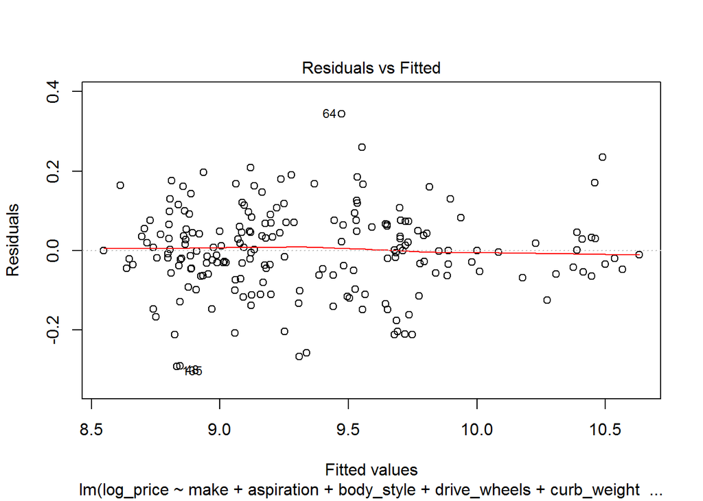

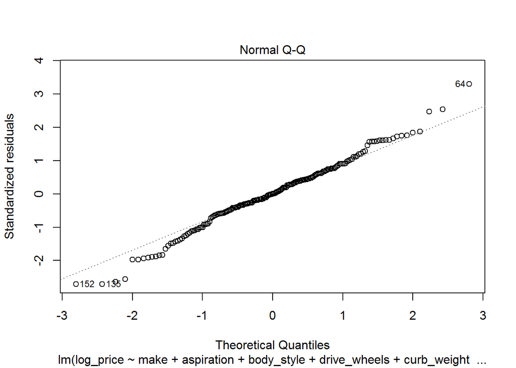

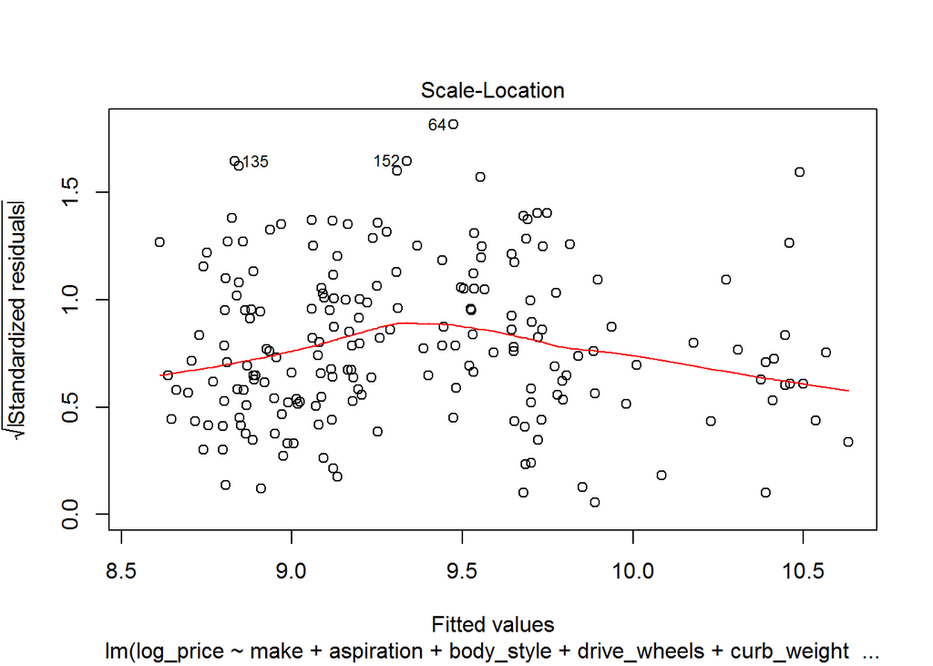

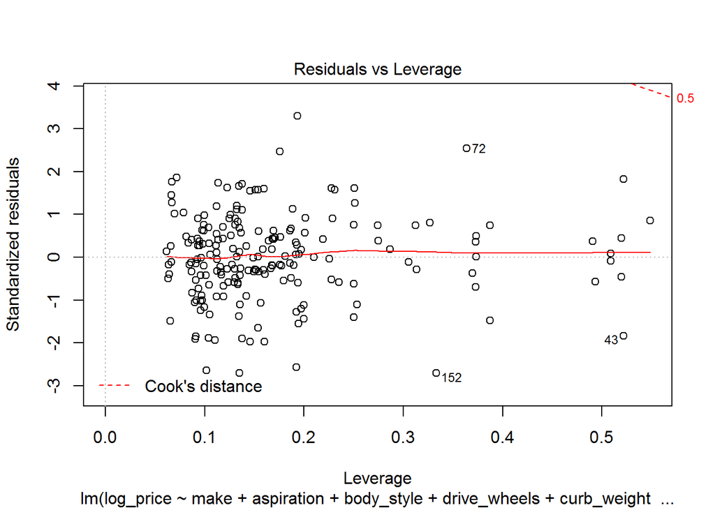

```r
plot(ap_lmstep)
```

Finally we, compare the baseline model and the step-wise model with ANOVA.

```r
anova(ap_lmstep, ap_lm)
```

```
## Analysis of Variance Table
##
## Model 1: log_price ~ make + aspiration + body_style + drive_wheels + curb_weight +
##     engine_type + engine_size + city_mpg
## Model 2: log_price ~ make + fuel_type + aspiration + body_style + drive_wheels +
##     length + curb_weight + engine_type + num_of_cylinders + engine_size +
##     city_mpg
##   Res.Df    RSS Df Sum of Sq     F Pr(>F)
## 1    164 2.2057
## 2    158 2.1302  6  0.075472 0.933  0.473
```

Fail to reject the null hypothesis, indicating that there is no statistical difference between the models.